# Lab6

Kwon Yong Chan

2021 2 15

## Lab6. 사례연구: 2000년 미 대선

florida 데이터는 67개 카운티 별로 13개의 정보가 기록되어 있다. 우리는 이중 BUSH(부시 후보의 득표)를 예측변수로, BUCHANAN(뷰캐넌 후보의 득표)를 반응변수로 사용하여 회귀분석을 실시한다. 이떄 with 함수는 본 실습파일에서는 구현이 안되는데 각자의 pc에서 콘솔창에 해당 명령어를 입력하면 우측 하단 ‘plots’ 세션에 plot이 그려지면서 커서가 십자모양으로 바뀌는데 이때 이상치 2개 지점을 클릭해주면 county 이름이 나타나게 된다.

```r
library(UsingR)
```

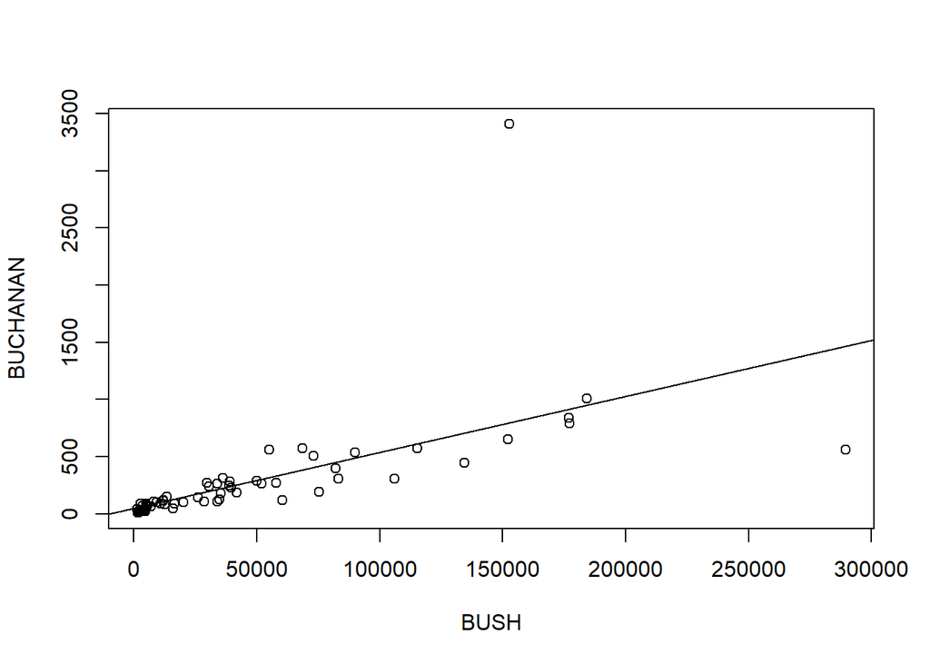

```
## integer(0)
```

```r
attach(florida)

result.lm <- lm(BUCHANAN ~ BUSH)

plot(BUSH,BUCHANAN)
abline(result.lm)

with(florida,identify(BUSH,BUCHANAN,n=2, labels = County))
```

# 회귀분석 결과 알아보기

```r
summary(result.lm)
```

```
##
## Call:
## lm(formula = BUCHANAN ~ BUSH)
##
## Residuals:
##     Min      1Q  Median      3Q     Max
## -907.50  -46.10  -29.19   12.26 2610.19
##
## Coefficients:
##              Estimate Std. Error t value Pr(>|t|)
## (Intercept) 4.529e+01  5.448e+01   0.831    0.409
## BUSH        4.917e-03  7.644e-04   6.432 1.73e-08 ***
## ---
## Signif. codes:  0 '***' 0.001 '**' 0.01 '*' 0.05 '.' 0.1 ' ' 1
##
## Residual standard error: 353.9 on 65 degrees of freedom
## Multiple R-squared:  0.3889, Adjusted R-squared:  0.3795
## F-statistic: 41.37 on 1 and 65 DF,  p-value: 1.727e-08
```

# 회귀모형 진단

왼쪽 상단의 잔차 vs 반응변수의 추정치의 산점도로 선형관계 가정에 대한 검증을 할 수 있다. 오른쪽 상단의 경우 정규성 가정을 검증하는 방법으로 오차항이 정규분포를 따른다면 직선모양을 관축할 수 있어야 한다. 왼쪽 하단의 그림은 등분산성에 대한 가정을 체크할 수 있다. 오른쪽 하단의 그림은 이상점 유무를 탐지하는데 유용하다.

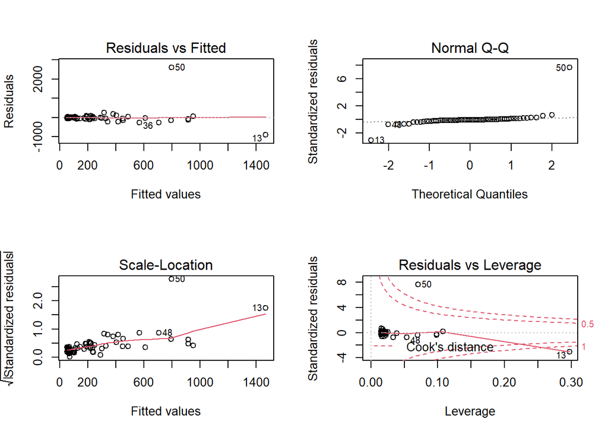

```r
par(mfrow=c(2,2))
plot(result.lm)
```